# Recommender System

Dhrubasattwata Roy Choudhury

### Recommender Systems

A recommender system, or a recommendation system, can be thought of as a subclass of information filtering system that seeks to predict the best “rating” or “preference” a user would give to an item which is typically obtained by optimizing for objectives like total clicks, total revenue, and overall sales.  
The basic principle of recommendations is that there are significant dependencies between user- and item-centric activity. For example, a user who is interested in sportswear is more likely to be interested in other sports wear brand, rather than a luxury apparel.

Classify recommenders into two categories:  
Prediction Problem: The first approach is where we would like to predict the rating value of a user-item combination.  
Ranking Problem: Recommend the top-k items for a particular user or determine the top-k users to target for a specific topic.

Types of recommender systems:  
Collaborative Filtering method: using data on ratings, and browsing behaviors (Interaction Data)  
Content Base Filtering method: about each users and items (Attribution Information)  
Knowledge-Based recommender system that is based on explicitly specified user requirements.

Hybrid Systems are then used to combined the advantages of these approaches to have a robust performing system across a wide variety of applications.

Implement a Collaborative Filtering Recommender System… In spite of a lot of known issues like the cold start problem, this kind of systems is broadly adopted, easier to model and known to deliver good results. The basic idea of CFR systems is that, if two users share the same interests in the past, e.g. they liked the same book or the same movie, they will also have similar tastes in the future.

### Import the packages

```r
library(recommenderlab)
```

```r
library(ggplot2)
library(data.table)
library(reshape2)
library(tidyverse)
library(caret)
library(lubridate)
library(scales)
library(ggthemes)
```

### Dataset

```r
movies <- read.csv("C:/Users/Dhruba/Desktop/GitHub/R - GitHub/data/movies.csv",stringsAsFactors=FALSE)
ratings<- read.csv("C:/Users/Dhruba/Desktop/GitHub/R - GitHub/data/ratings.csv")
```

### Data Exploration and Pre-processing

```r
head(movies)
```

```
##   movieId                              title
## 1       1                   Toy Story (1995)
## 2       2                     Jumanji (1995)
## 3       3            Grumpier Old Men (1995)
## 4       4           Waiting to Exhale (1995)
## 5       5 Father of the Bride Part II (1995)
## 6       6                        Heat (1995)
##                                        genres
## 1 Adventure|Animation|Children|Comedy|Fantasy
## 2                  Adventure|Children|Fantasy
## 3                              Comedy|Romance
## 4                        Comedy|Drama|Romance
## 5                                      Comedy
## 6                       Action|Crime|Thriller
```

```r
head(ratings)
```

```
##   userId movieId rating timestamp
## 1      1       1      4 964982703
## 2      1       3      4 964981247
## 3      1       6      4 964982224
## 4      1      47      5 964983815
## 5      1      50      5 964982931
## 6      1      70      3 964982400
```

Convert the genres present in the movie_data dataframe into a more usable format by the users.

```r
genres <- as.data.frame(movies$genres, stringsAsFactors=FALSE)

genres2 <- as.data.frame(tstrsplit(genres[,1], '[|]', type.convert=TRUE), stringsAsFactors=FALSE)
colnames(genres2) <- c(1:10)
unique(genres2[,1])
```

```
##  [1] "Adventure"          "Comedy"             "Action"
##  [4] "Drama"              "Crime"              "Children"
##  [7] "Mystery"            "Animation"          "Documentary"
## [10] "Thriller"           "Horror"             "Fantasy"
## [13] "Western"            "Film-Noir"          "Romance"
## [16] "Sci-Fi"             "Musical"            "War"
## [19] "(no genres listed)"
```

```r
genre_list <- c("Action", "Adventure", "Animation", "Children",
                "Comedy", "Crime","Documentary", "Drama", "Fantasy",
                "Film-Noir", "Horror", "Musical", "Mystery","Romance",
                "Sci-Fi", "Thriller", "War", "Western") # we have 18 genres in total

genre_matrix <- matrix(0,9743,18) #empty matrix, 10330=no of movies+1, 18=no of genres
genre_matrix[1,] <- genre_list #set first row to genre list
colnames(genre_matrix) <- genre_list #set column names to genre list

#iterate through matrix
for (i in 1:nrow(genres2)) {
  for (c in 1:ncol(genres2)) {
    genmat_col = which(genre_matrix[1,] == genres2[i,c])
    genre_matrix[i+1,genmat_col] <- 1
  }
}

#convert into dataframe
genre_matrix2 <- as.data.frame(genre_matrix[-1,], stringsAsFactors=FALSE) #remove first row, which was the genre list
for (c in 1:ncol(genre_matrix2)) {
  genre_matrix2[,c] <- as.integer(genre_matrix2[,c])
} #convert from characters to integers

#Create a matrix to search for a movie by genre:
years <- as.data.frame(movies$title, stringsAsFactors=FALSE)
library(data.table)
substrRight <- function(x, n){
  substr(x, nchar(x)-n+1, nchar(x))
}
years <- as.data.frame(substr(substrRight(substrRight(years$`movies$title`, 6),5),1,4))
```

### Search Matrix

Create a ‘search matrix’ that will allow us to perform an easy search of the films by specifying the genre present in our list.

```r
search_matrix <- cbind(movies[,1], substr(movies[,2],1,nchar(movies[,2])-6), years, genre_matrix2)
colnames(search_matrix) <- c("movieId", "title", "year", genre_list)
head(search_matrix)
```

```
##   movieId                        title year Action Adventure Animation Children
## 1       1                   Toy Story  1995      0         1         1        1
## 2       2                     Jumanji  1995      0         1         0        1
## 3       3            Grumpier Old Men  1995      0         0         0        0
## 4       4           Waiting to Exhale  1995      0         0         0        0
## 5       5 Father of the Bride Part II  1995      0         0         0        0
## 6       6                        Heat  1995      1         0         0        0
##   Comedy Crime Documentary Drama Fantasy Film-Noir Horror Musical Mystery
## 1      1     0           0     0       1         0      0       0       0
## 2      0     0           0     0       1         0      0       0       0
## 3      1     0           0     0       0         0      0       0       0
## 4      1     0           0     1       0         0      0       0       0
## 5      1     0           0     0       0         0      0       0       0
## 6      0     1           0     0       0         0      0       0       0
##   Romance Sci-Fi Thriller War Western
## 1       0      0        0   0       0
## 2       0      0        0   0       0
## 3       1      0        0   0       0
## 4       1      0        0   0       0
## 5       0      0        0   0       0
## 6       0      0        1   0       0
```

### Create a user profile

```r
binaryratings <- ratings
```

Ratings of 4 and 5 are mapped to 1, representing likes, and ratings of 3 and below are mapped to -1, representing dislikes:

```r
for (i in 1:nrow(binaryratings)){
  if (binaryratings[i,3] > 3){
    binaryratings[i,3] <- 1
  }
  else{
    binaryratings[i,3] <- -1
  }
}

# convert binaryratings matrix to the correct format:
binaryratings2 <- dcast(binaryratings, movieId~userId, value.var = "rating", na.rm=FALSE)

for (i in 1:ncol(binaryratings2)){
  binaryratings2[which(is.na(binaryratings2[,i]) == TRUE),i] <- 0
}
binaryratings2 = binaryratings2[,-1] #remove movieIds col. Rows are movieIds, cols are userIds
```

### Remove rows that are not rated from movies dataset

```r
movieIds <- length(unique(movies$movieId)) #10329
ratingmovieIds <- length(unique(ratings$movieId)) #10325
movies2 <- movies[-which((movies$movieId %in% ratings$movieId) == FALSE),]
rownames(movies2) <- NULL
```

### Remove rows that are not rated from genre_matrix2

```r
genre_matrix3 <- genre_matrix2[-which((movies$movieId %in% ratings$movieId) == FALSE),]
rownames(genre_matrix3) <- NULL
```

### Creating USER PROFILES

Calculate the dot product of the genre matrix and the ratings matrix and obtain the user profiles

```r
result = matrix(0,18,668) # here, 668=no of users/raters, 18=no of genres
for (c in 1:ncol(binaryratings2)){
  for (i in 1:ncol(genre_matrix3)){
    result[i,c] <- sum((genre_matrix3[,i]) * (binaryratings2[,c])) #ratings per genre
  }
}

#Convert to Binary scale
for (c in 1:ncol(result)){
  for (i in 1:nrow(result)){
    if (result[i,c] < 0){
      result[i,c] <- 0
    }
    else {
      result[i,c] <- 1
    }
  }
}
```

### BUILD THE MODEL: User-Based Collaborative Filtering Approach RECOMMENDATION ENGINE

```r
#Create ratings matrix. Rows = userId, Columns = movieId
ratingmat <- dcast(ratings, userId~movieId, value.var = "rating", na.rm=FALSE)
ratingmat <- as.matrix(ratingmat[,-1]) #remove userIds

# Method: UBCF
# Similarity Calculation Method: Cosine Similarity
# Nearest Neighbors: 30

#Convert rating matrix into a recommenderlab sparse matrix
ratingmat <- as(ratingmat, "realRatingMatrix")

# Determine how similar the first four users are with each other
# create similarity matrix
similarity_users <- similarity(ratingmat[1:4, ],
                               method = "cosine",
                               which = "users")
as.matrix(similarity_users)
```

```
##           1  2         3         4
## 1 0.0000000  1 0.7919033 0.9328096
## 2 1.0000000  0        NA 1.0000000
## 3 0.7919033 NA 0.0000000 1.0000000
## 4 0.9328096  1 1.0000000 0.0000000
```

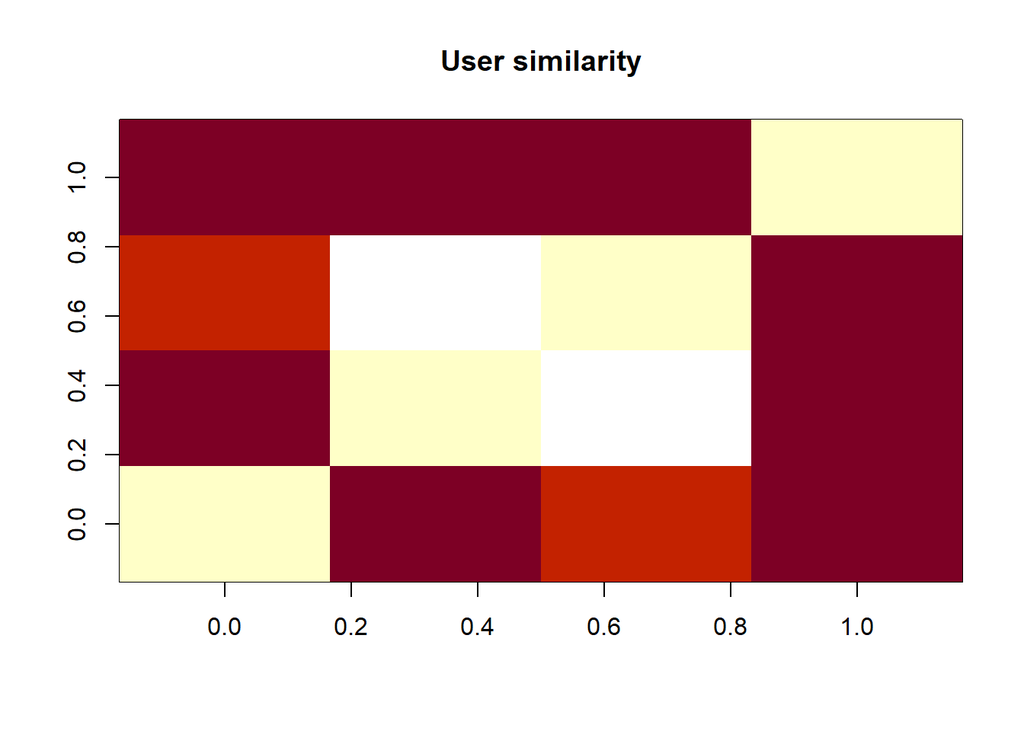

```r
image(as.matrix(similarity_users), main = "User similarity")
```

```r
# compute similarity between
# the first four movies
similarity_items <- similarity(ratingmat[, 1:4], method =
                                 "cosine", which = "items")
as.matrix(similarity_items)
```

```
##           1         2         3         4
## 1 0.0000000 0.9644641 0.9715415 0.9838699
## 2 0.9644641 0.0000000 0.9389013 0.9609877
## 3 0.9715415 0.9389013 0.0000000 1.0000000
## 4 0.9838699 0.9609877 1.0000000 0.0000000
```

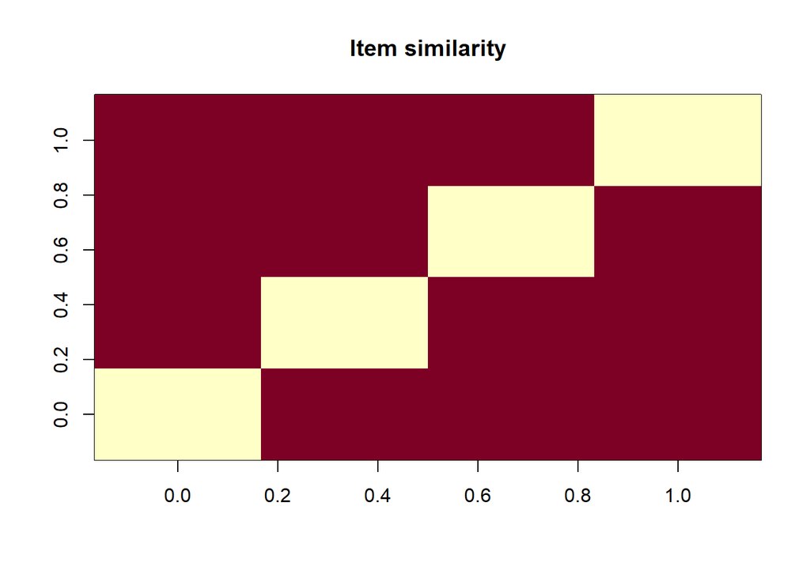

```r
image(as.matrix(similarity_items), main = "Item similarity")
```

```r
# Exploring values of ratings:
vector_ratings <- as.vector(ratingmat@data)
unique(vector_ratings) # what are unique values of ratings
```

```
##  [1] 4.0 0.0 4.5 2.5 3.5 3.0 5.0 0.5 2.0 1.5 1.0
```

```r
table_ratings <- table(vector_ratings) # what is the count of each rating value
table_ratings
```

```
## vector_ratings
##       0     0.5       1     1.5       2     2.5       3     3.5       4     4.5
## 5830804    1370    2811    1791    7551    5550   20047   13136   26818    8551
##       5
##   13211
```

### Visualize the rating:

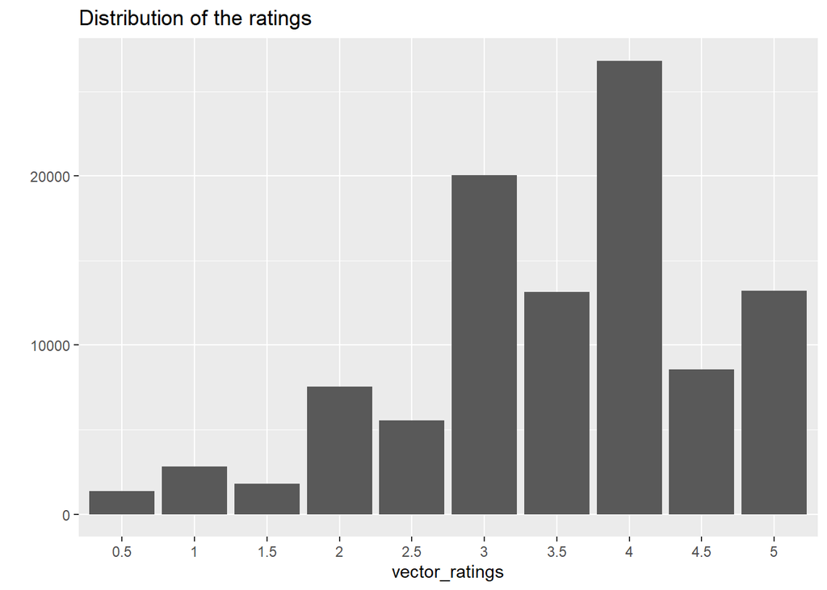

```r
vector_ratings <- vector_ratings[vector_ratings != 0] # rating == 0 are NA values
vector_ratings <- factor(vector_ratings)

qplot(vector_ratings) +
  ggtitle("Distribution of the ratings")
```

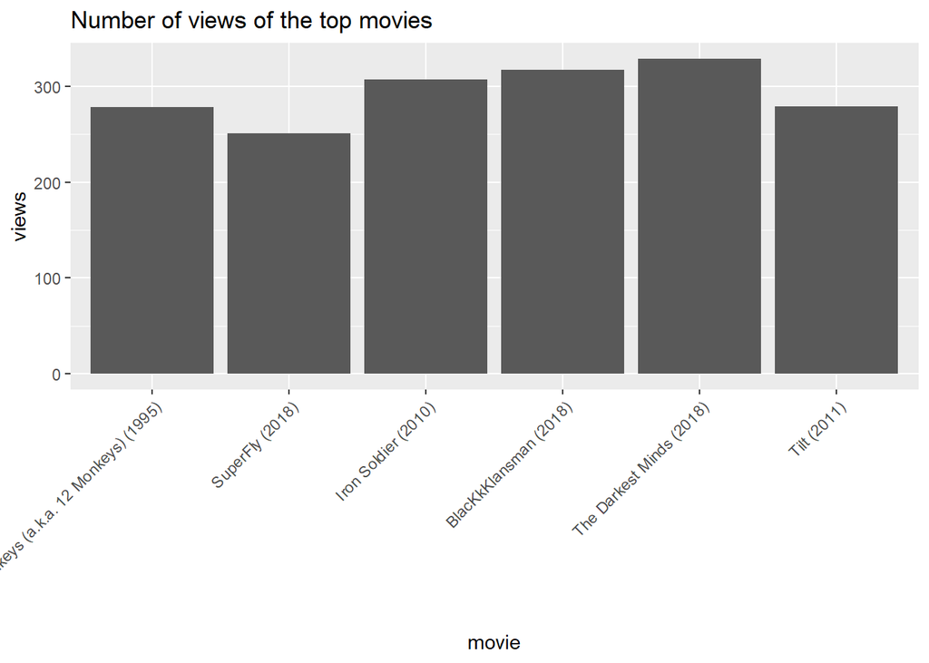

```r
# Exploring viewings of movies:
views_per_movie <- colCounts(ratingmat) # count views for each movie

table_views <- data.frame(movie = names(views_per_movie),
                          views = views_per_movie) # create dataframe of views
table_views <- table_views[order(table_views$views,
                                 decreasing = TRUE), ] # sort by number of views

ggplot(table_views[1:6, ], aes(x = movie, y = views)) +
  geom_bar(stat="identity") +
  theme(axis.text.x = element_text(angle = 45, hjust = 1)) +
  scale_x_discrete(labels=subset(movies2, movies2$movieId == table_views$movie)$title) +
  ggtitle("Number of views of the top movies")
```

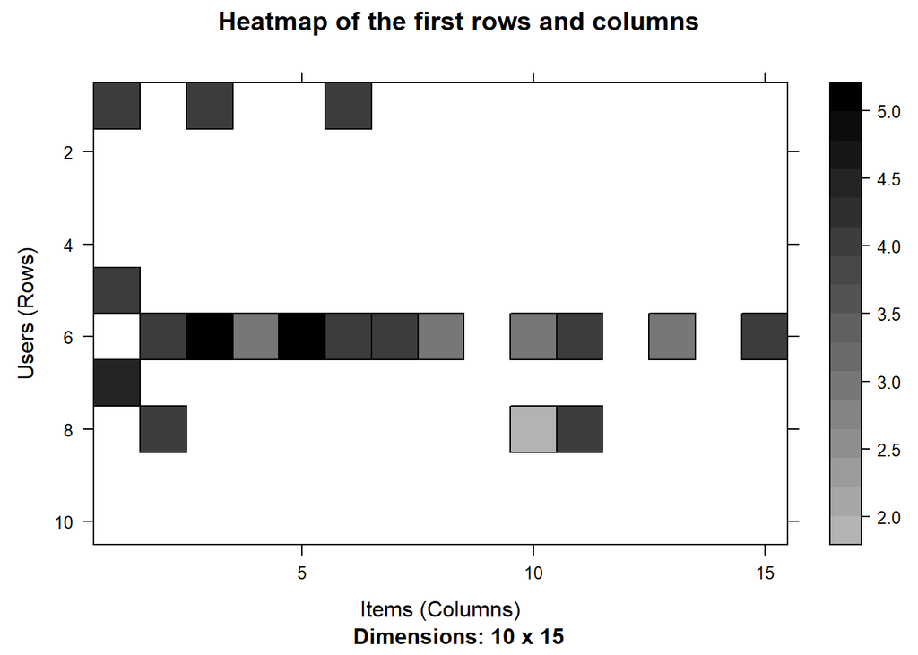

```r
#Visualizing the matrix:
image(ratingmat[1:10, 1:15], main = "Heatmap of the first rows and columns")
```

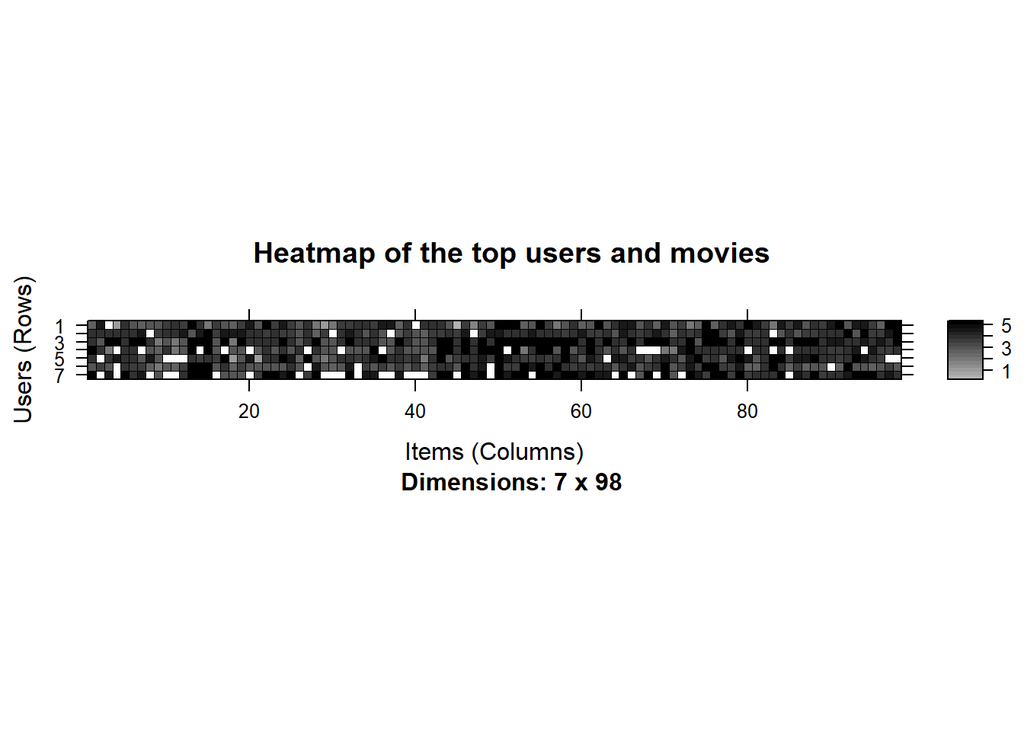

```r
image(ratingmat[rowCounts(ratingmat) > quantile(rowCounts(ratingmat), 0.99),
                 colCounts(ratingmat) > quantile(colCounts(ratingmat), 0.99)],
      main = "Heatmap of the top users and movies")
```

### Normalize the data

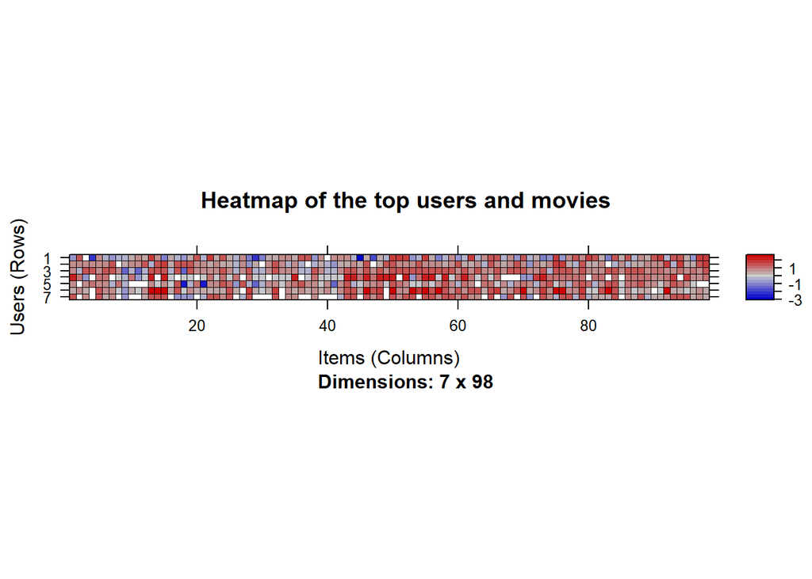

```r
ratingmat_norm <- normalize(ratingmat)
image(ratingmat_norm[rowCounts(ratingmat_norm) > quantile(rowCounts(ratingmat_norm), 0.99),
                colCounts(ratingmat_norm) > quantile(colCounts(ratingmat_norm), 0.99)],
      main = "Heatmap of the top users and movies")
```

### THE MODEL: User-Based Collaborative Filtering Approach RECOMMENDATION ENGINE

```r
recommender_model <- Recommender(ratingmat_norm,
                                 method = "UBCF",
                                 param=list(method="Cosine",nn=30))
recommender_model
```

```
## Recommender of type 'UBCF' for 'realRatingMatrix'
## learned using 610 users.
```

```r
model_details <- getModel(recommender_model)
model_details$data
```

```
## 610 x 9724 rating matrix of class 'realRatingMatrix' with 100836 ratings.
## Normalized using center on rows.
```

```r
## For prediction using the model
recom <- predict(recommender_model,
                 ratingmat[1],
                 n=10) #Obtain top 10 recommendations for 1st user in dataset

recom_list <- as(recom,
                 "list") #convert recommenderlab object to readable list
```

### For predictions

```r
user1 <- recom@items[[1]] # recommendation for the first user
movies_user1 <- recom@itemLabels[user1]
movies_user2 <- movies_user1
for (index in 1:10){
  movies_user2[index] <- as.character(subset(movies,
                                             movies$movieId == movies_user1[index])$title)
}
movies_user2
```

```
##  [1] "Bossa Nova (2000)"
##  [2] "Maltese Falcon, The (1941)"
##  [3] "Michael Clayton (2007)"
##  [4] "Twelve Monkeys (a.k.a. 12 Monkeys) (1995)"
##  [5] "3-Iron (Bin-jip) (2004)"
##  [6] "Enemy at the Gates (2001)"
##  [7] "Serenity (2005)"
##  [8] "Watchmen (2009)"
##  [9] "Walk to Remember, A (2002)"
## [10] "Tristan & Isolde (2006)"
```